# Gender Inequality Change, 2010–2019

LingziZhuo

## Research question

How did gender inequality change across countries between 2010 and 2019?

## Measure of change

We calculate change as:

GII change = GII in 2019 - GII in 2010

- A negative value indicates a decrease in gender inequality.
- A positive value indicates an increase in gender inequality.
- Zero indicates no change in the reported index.

## Check the project folder

```r
getwd()
```

```
## [1] "C:/Users/A/Documents/Codex/2026-10-29/https-andrewmaclachlan-github-io-casa0005repo-git/outputs/casa0005-practical4"
```

## Read the original data

```r
gii_raw <- read.csv(
  "data/HDR25_Composite_indices_complete_time_series.csv"
)

dim(gii_raw)
```

```
## [1]  206 1112
```

```r
head(names(gii_raw), 20)
```

```
##  [1] "iso3"          "country"       "hdicode"       "region"
##  [5] "hdi_rank_2023" "hdi_1990"      "hdi_1991"      "hdi_1992"
##  [9] "hdi_1993"      "hdi_1994"      "hdi_1995"      "hdi_1996"
## [13] "hdi_1997"      "hdi_1998"      "hdi_1999"      "hdi_2000"
## [17] "hdi_2001"      "hdi_2002"      "hdi_2003"      "hdi_2004"
```

## Locate the GII columns

```r
required_columns <- c("iso3", "country", "gii_2010", "gii_2019")

required_columns %in% names(gii_raw)
```

```
## [1] TRUE TRUE TRUE TRUE
```

```r
str(gii_raw[required_columns])
```

```
## 'data.frame':    206 obs. of  4 variables:
##  $ iso3    : chr  "AFG" "ALB" "DZA" "AND" ...
##  $ country : chr  "Afghanistan" "Albania" "Algeria" "Andorra" ...
##  $ gii_2010: num  0.704 0.192 0.508 NA 0.556 NA 0.37 0.352 0.137 0.105 ...
##  $ gii_2019: num  0.676 0.131 0.385 NA 0.536 NA 0.283 0.216 0.079 0.052 ...
```

```r
head(gii_raw[required_columns])
```

```
##   iso3             country gii_2010 gii_2019
## 1  AFG         Afghanistan    0.704    0.676
## 2  ALB             Albania    0.192    0.131
## 3  DZA             Algeria    0.508    0.385
## 4  AND             Andorra       NA       NA
## 5  AGO              Angola    0.556    0.536
## 6  ATG Antigua and Barbuda       NA       NA
```

## Calculate GII change

```r
gii <- gii_raw[required_columns]

gii$gii_change <- gii$gii_2019 - gii$gii_2010

head(gii)
```

```
##   iso3             country gii_2010 gii_2019 gii_change
## 1  AFG         Afghanistan    0.704    0.676     -0.028
## 2  ALB             Albania    0.192    0.131     -0.061
## 3  DZA             Algeria    0.508    0.385     -0.123
## 4  AND             Andorra       NA       NA         NA
## 5  AGO              Angola    0.556    0.536     -0.020
## 6  ATG Antigua and Barbuda       NA       NA         NA
```

```r
colSums(is.na(gii[c("gii_2010", "gii_2019", "gii_change")]))
```

```
##   gii_2010   gii_2019 gii_change
##         41         26         41
```

## Check country identifiers

```r
anyDuplicated(gii$iso3)
```

```
## [1] 0
```

```r
tail(gii, 12)
```

```
##          iso3                         country gii_2010 gii_2019 gii_change
## 195       ZWE                        Zimbabwe    0.595    0.525     -0.070
## 196  ZZA.VHHD     Very high human development    0.214    0.141     -0.073
## 197   ZZB.HHD          High human development    0.387    0.335     -0.052
## 198   ZZC.MHD        Medium human development    0.585    0.543     -0.042
## 199   ZZD.LHD           Low human development    0.625    0.582     -0.043
## 200    ZZE.AS                     Arab States    0.588    0.541     -0.047
## 201   ZZF.EAP       East Asia and the Pacific    0.366    0.318     -0.048
## 202   ZZG.ECA         Europe and Central Asia    0.307    0.232     -0.075
## 203   ZZH.LAC Latin America and the Caribbean    0.431    0.390     -0.041
## 204    ZZI.SA                      South Asia    0.559    0.500     -0.059
## 205   ZZJ.SSA              Sub-Saharan Africa    0.603    0.575     -0.028
## 206 ZZK.WORLD                           World    0.504    0.464     -0.040
```

## Separate country records from aggregates

```r
is_country <- grepl("^[A-Z]{3}$", gii$iso3)

gii[!is_country, c("iso3", "country")]
```

```
##          iso3                         country
## 196  ZZA.VHHD     Very high human development
## 197   ZZB.HHD          High human development
## 198   ZZC.MHD        Medium human development
## 199   ZZD.LHD           Low human development
## 200    ZZE.AS                     Arab States
## 201   ZZF.EAP       East Asia and the Pacific
## 202   ZZG.ECA         Europe and Central Asia
## 203   ZZH.LAC Latin America and the Caribbean
## 204    ZZI.SA                      South Asia
## 205   ZZJ.SSA              Sub-Saharan Africa
## 206 ZZK.WORLD                           World
```

```r
gii_countries <- gii[is_country, ]

nrow(gii_countries)
```

```
## [1] 195
```

```r
sum(!is.na(gii_countries$gii_change))
```

```
## [1] 154
```

```r
library(sf)
```

## Read the world boundaries

```r
world <- st_read(
  "data/World_Countries_(Generalized)_2173680399808997149.geojson",
  quiet = TRUE
)

nrow(world)
```

```
## [1] 251
```

```r
names(world)
```

```
## [1] "FID"        "COUNTRY"    "ISO"        "COUNTRYAFF" "AFF_ISO"
## [6] "geometry"
```

```r
head(st_drop_geometry(world))
```

```
##   FID        COUNTRY ISO    COUNTRYAFF AFF_ISO
## 1   1    Afghanistan  AF   Afghanistan      AF
## 2   2        Albania  AL       Albania      AL
## 3   3        Algeria  DZ       Algeria      DZ
## 4   4 American Samoa  AS United States      US
## 5   5        Andorra  AD       Andorra      AD
## 6   6         Angola  AO        Angola      AO
```

## Standardise country codes

```r
library(countrycode)

world$iso3 <- countrycode(
  world$ISO,
  origin = "iso2c",
  destination = "iso3c"
)

head(st_drop_geometry(world)[c("COUNTRY", "ISO", "iso3")])
```

```
##          COUNTRY ISO iso3
## 1    Afghanistan  AF  AFG
## 2        Albania  AL  ALB
## 3        Algeria  DZ  DZA
## 4 American Samoa  AS  ASM
## 5        Andorra  AD  AND
## 6         Angola  AO  AGO
```

```r
st_drop_geometry(world)[is.na(world$iso3), c("COUNTRY", "ISO")]
```

```
## [1] COUNTRY ISO
## <0 rows> (or 0-length row.names)
```

## Join GII data to world boundaries

```r
match_row <- match(world$iso3, gii_countries$iso3)

world_gii <- world

world_gii$gii_2010 <- gii_countries$gii_2010[match_row]
world_gii$gii_2019 <- gii_countries$gii_2019[match_row]
world_gii$gii_change <- gii_countries$gii_change[match_row]

nrow(world_gii)
```

```
## [1] 251
```

```r
sum(!is.na(match_row))
```

```
## [1] 197
```

```r
sum(!is.na(world_gii$gii_change))
```

```
## [1] 157
```

```r
head(st_drop_geometry(world_gii)[
  c("COUNTRY", "iso3", "gii_2010", "gii_2019", "gii_change")
])
```

```
##          COUNTRY iso3 gii_2010 gii_2019 gii_change
## 1    Afghanistan  AFG    0.704    0.676     -0.028
## 2        Albania  ALB    0.192    0.131     -0.061
## 3        Algeria  DZA    0.508    0.385     -0.123
## 4 American Samoa  ASM       NA       NA         NA
## 5        Andorra  AND       NA       NA         NA
## 6         Angola  AGO    0.556    0.536     -0.020
```

## Check repeated map codes

```r
repeated_code <- duplicated(world$iso3) |
  duplicated(world$iso3, fromLast = TRUE)

st_drop_geometry(world)[
  repeated_code,
  c("COUNTRY", "ISO", "iso3")
]
```

```
##                         COUNTRY ISO iso3
## 16                       Azores  PT  PRT
## 28                      Bonaire  BQ  BES
## 43                     Canarias  ES  ESP
## 82  French Southern Territories  TF  ATF
## 89             Glorioso Islands  TF  ATF
## 117         Juan De Nova Island  TF  ATF
## 133                     Madeira  PT  PRT
## 180                    Portugal  PT  PRT
## 187                        Saba  BQ  BES
## 189             Saint Eustatius  BQ  BES
## 214                       Spain  ES  ESP
```

## Check coverage by unique country code

```r
length(unique(world_gii$iso3[!is.na(match_row)]))
```

```
## [1] 194
```

```r
length(unique(
  world_gii$iso3[!is.na(world_gii$gii_change)]
))
```

```
## [1] 154
```

```r
gii_countries[
  !gii_countries$iso3 %in% world$iso3,
  c("country", "iso3", "gii_change")
]
```

```
##                   country iso3 gii_change
## 75 Hong Kong, China (SAR)  HKG         NA
```

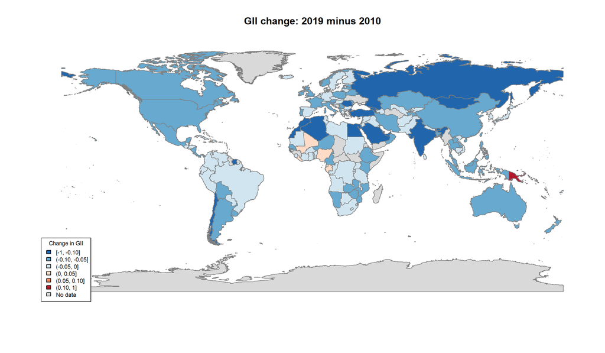

```r
breaks <- c(-1, -0.10, -0.05, 0, 0.05, 0.10, 1)

palette <- c(
  "#2166AC", "#67A9CF", "#D1E5F0",
  "#FDDBC7", "#EF8A62", "#B2182B"
)

change_group <- cut(
  world_gii$gii_change,
  breaks = breaks,
  include.lowest = TRUE
)

map_colours <- palette[as.integer(change_group)]
map_colours[is.na(world_gii$gii_change)] <- "grey85"

plot(
  st_geometry(world_gii),
  col = map_colours,
  border = "grey50",
  main = "GII change: 2019 minus 2010"
)

legend(
  "bottomleft",
  legend = c(
    "[-1, -0.10]", "(-0.10, -0.05]", "(-0.05, 0]",
    "(0, 0.05]", "(0.05, 0.10]", "(0.10, 1]",
    "No data"
  ),
  fill = c(palette, "grey85"),
  title = "Change in GII",
  cex = 0.7,
  bg = "white"
)
```

## Summarise the direction of change

```r
change <- gii_countries$gii_change

c(
  decreased = sum(change < 0, na.rm = TRUE),
  unchanged = sum(change == 0, na.rm = TRUE),
  increased = sum(change > 0, na.rm = TRUE),
  missing = sum(is.na(change))
)
```

```
## decreased unchanged increased   missing
##       145         0         9        41
```

## Findings and limitations

Among the 154 countries or territories with GII data for both 2010 and 2019, 145 (94.2%) recorded a decrease in GII and 9 (5.8%) recorded an increase. None had an exactly zero change in the reported values.

A further 41 records lacked sufficient data to calculate change. The findings therefore describe countries and territories with available data, rather than every country or territory.

The map shows changes in GII, not the level of GII in 2019. A large decrease does not necessarily mean that the final level of gender inequality was low. This descriptive comparison does not establish the causes of change.

## Data sources and method

GII data were obtained from the UNDP Human Development Report 2025 composite indices time-series dataset. Values for 2010 and 2019 were taken from the same release.

Source: https://hdr.undp.org/data-center/documentation-and-downloads

World boundaries were obtained from the World Countries Generalized dataset in GeoJSON format.

Source: https://hub.arcgis.com/datasets/2b93b06dc0dc4e809d3c8db5cb96ba69_0/explore

Eleven aggregate records were excluded from the GII table. Two-letter boundary codes were converted to three-letter ISO codes using the countrycode package. The datasets were then matched by these codes.

Change was calculated as GII in 2019 minus GII in 2010. Missing values were retained. Summary counts used the GII country table to avoid counting separate map parts more than once.

## Reproducing the analysis

Open the RStudio project. The required packages are rmarkdown, sf and countrycode.

Place the original UNDP CSV and world boundaries GeoJSON in the data folder, retaining the filenames used in this document. Open homework_gii.Rmd and click Knit.